#### Are there differences in activity patterns between weekdays and weekends?

For this part the weekdays() function may be of some help here. Use the dataset with the filled-in missing values for this part.

1. Create a new factor variable in the dataset with two levels - “weekday” and “weekend” indicating whether a given date is a weekday or weekend day.
2. Make a panel plot containing a time series plot (i.e. type = “l”) of the 5-minute interval (x-axis) and the average number of steps taken, averaged across all weekday days or weekend days (y-axis). See the README file in the GitHub repository to see an example of what this plot should look like using simulated data.

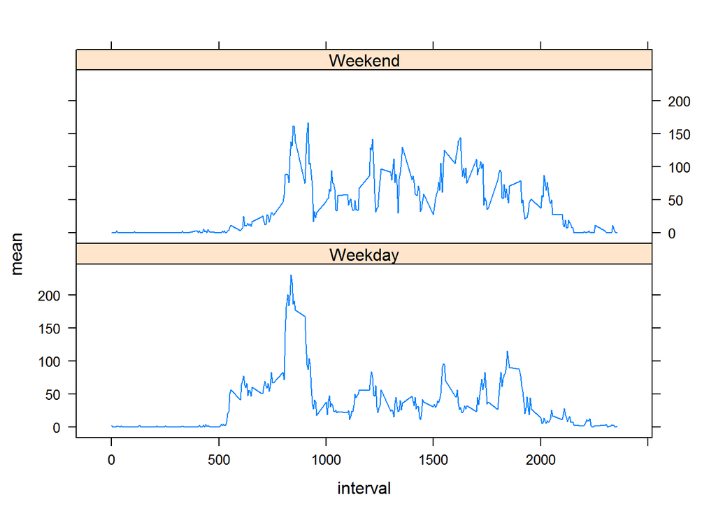

```r
Activity2<-ActivityNoNAsMeanintervalDF
Activity2$date<-as.Date(Activity2$date)
Activity2<-mutate(Activity2,weekday=weekdays(date))
Activity2$weekday[!Activity2$weekday=="Saturday" & !Activity2$weekday=="Sunday"]<-"Weekday"
Activity2$weekday[Activity2$weekday=="Saturday" | Activity2$weekday=="Sunday"]<-"Weekend"
Activity2line<-group_by(Activity2,interval,weekday)
Activity2linesummary<-summarize(Activity2line,mean=mean(steps))
Activity2linesummary<-as.data.frame(Activity2linesummary)
Activity2linesummary$weekday<-as.factor(Activity2linesummary$weekday)
library(lattice)
xyplot(mean ~ interval | weekday, data=Activity2linesummary, layout=c(1,2), type="l")
```